# Refactoring DataReply

Luca Ganugi, Vincenzo Lio, Matteo Frizzi

21 giugno 2017

Carico le librerie necessarie:

```r
library(data.table)
library(zoo)
library(dplyr)
library(stringi)
library(bizdays)
library(lubridate)
library(timeDate)
library(htmltab)
library(reshape2)
library(httr)
```

```r
number = c(1,2,3)
animal = c("cat","dog","mouse")
df1 = data.frame(number,animal)
df1
```

```
##   number animal
## 1      1    cat
## 2      2    dog
## 3      3  mouse
```

```r
df1['animal']
```

```
##   animal
## 1    cat
## 2    dog
## 3  mouse
```

```r
df1$animal
```

```
## [1] cat   dog   mouse
## Levels: cat dog mouse
```

# Loading data (and basic statistics / visualization)

```r
names =c("State_Code", "County_Code", "Census_Tract_Number", "NUM_ALL", "NUM_FHA", "PCT_NUM_FHA", "AMT_ALL", "AMT_FHA", "PCT_AMT_FHA")
df = read.csv(file='C:/Users/luca.ganugi/Desktop/Master MABIDA/Gigli/Data Reply/fha_by_tract.csv',header=FALSE, col.names=names)
head(df,3)
```

```
##   State_Code County_Code Census_Tract_Number NUM_ALL NUM_FHA PCT_NUM_FHA
## 1          8          75                  NA       1       1         100
## 2         28          49              103.01       1       1         100
## 3         40           3                  NA       1       1         100
##   AMT_ALL AMT_FHA PCT_AMT_FHA
## 1     258     258         100
## 2      71      71         100
## 3     215     215         100
```

```r
df$GEOID = df$Census_Tract_Number*100 + 10**6 * df$County_Code + 10**9 * df$State_Code
head(df)
```

```
##   State_Code County_Code Census_Tract_Number NUM_ALL NUM_FHA PCT_NUM_FHA
## 1          8          75                  NA       1       1         100
## 2         28          49              103.01       1       1         100
## 3         40           3                  NA       1       1         100
## 4         39         113              603.00       3       3         100
## 5         12         105              124.04       2       2         100
## 6         12          86             9808.00       1       1         100
##   AMT_ALL AMT_FHA PCT_AMT_FHA       GEOID
## 1     258     258         100          NA
## 2      71      71         100 28049010301
## 3     215     215         100          NA
## 4     206     206         100 39113060300
## 5     303     303         100 12105012404
## 6     188     188         100 12086980800
```

Per rimuovere una colonna (permanentemente a differenza di Pandas, dove è richiesto il comando inplace=true):

```r
df$GEOID = NULL
head(df)
```

```
##   State_Code County_Code Census_Tract_Number NUM_ALL NUM_FHA PCT_NUM_FHA
## 1          8          75                  NA       1       1         100
## 2         28          49              103.01       1       1         100
## 3         40           3                  NA       1       1         100
## 4         39         113              603.00       3       3         100
## 5         12         105              124.04       2       2         100
## 6         12          86             9808.00       1       1         100
##   AMT_ALL AMT_FHA PCT_AMT_FHA
## 1     258     258         100
## 2      71      71         100
## 3     215     215         100
## 4     206     206         100
## 5     303     303         100
## 6     188     188         100
```

Reintroduco la variabile GEOID perchè servirà dopo:

```r
df$GEOID = df$Census_Tract_Number*100 + 10**6 * df$County_Code + 10**9 * df$State_Code
```

Non visualizzo la prima riga:

```r
head(df[-1,])
```

```
##   State_Code County_Code Census_Tract_Number NUM_ALL NUM_FHA PCT_NUM_FHA
## 2         28          49              103.01       1       1         100
## 3         40           3                  NA       1       1         100
## 4         39         113              603.00       3       3         100
## 5         12         105              124.04       2       2         100
## 6         12          86             9808.00       1       1         100
## 7         39          35             1202.00       1       1         100
##   AMT_ALL AMT_FHA PCT_AMT_FHA       GEOID
## 2      71      71         100 28049010301
## 3     215     215         100          NA
## 4     206     206         100 39113060300
## 5     303     303         100 12105012404
## 6     188     188         100 12086980800
## 7      19      19         100 39035120200
```

Non visualizzo la prima colonna:

```r
head(df[,-1])
```

```
##   County_Code Census_Tract_Number NUM_ALL NUM_FHA PCT_NUM_FHA AMT_ALL
## 1          75                  NA       1       1         100     258
## 2          49              103.01       1       1         100      71
## 3           3                  NA       1       1         100     215
## 4         113              603.00       3       3         100     206
## 5         105              124.04       2       2         100     303
## 6          86             9808.00       1       1         100     188
##   AMT_FHA PCT_AMT_FHA       GEOID
## 1     258         100          NA
## 2      71         100 28049010301
## 3     215         100          NA
## 4     206         100 39113060300
## 5     303         100 12105012404
## 6     188         100 12086980800
```

Pare non sia possibile introdurre un index con dei valori non univoci:

```r
#row.names(df) = df$State_Code
```

Sembra che tramite la libreria data.table sia possibile fare il multi-index:

```r
library(data.table)
datatable <- as.data.table(df)
setkey(datatable, State_Code,County_Code)
head(datatable)
```

```
##    State_Code County_Code Census_Tract_Number NUM_ALL NUM_FHA PCT_NUM_FHA
## 1:         NA          NA                  NA    9477    1932    20.38620
## 2:          1          NA                  NA      15       1     6.66667
## 3:          1           1                 201       8       5    62.50000
## 4:          1           1                 203      38      20    52.63160
## 5:          1           1                 204      30      16    53.33330
## 6:          1           1                 207      17       7    41.17650
##    AMT_ALL AMT_FHA PCT_AMT_FHA      GEOID
## 1: 1575871  331515    21.03690         NA
## 2:    2812     114     4.05405         NA
## 3:    1319     754    57.16450 1001020100
## 4:    3605    1928    53.48130 1001020300
## 5:    3628    1800    49.61410 1001020400
## 6:    1832     889    48.52620 1001020700
```

```r
#Percentage of mortages in each census tract insured by FHA
summary(df$PCT_AMT_FHA)
```

```
##    Min. 1st Qu.  Median    Mean 3rd Qu.    Max.
##    0.00   10.78   24.75   29.70   44.21  100.00
```

```r
summary(df)
```

```
##    State_Code     County_Code     Census_Tract_Number    NUM_ALL
##  Min.   : 1.00   Min.   :  1.00   Min.   :   1        Min.   :   1.00
##  1st Qu.:13.00   1st Qu.: 29.00   1st Qu.: 103        1st Qu.:  13.00
##  Median :28.00   Median : 63.00   Median : 442        Median :  27.00
##  Mean   :28.32   Mean   : 85.61   Mean   :2535        Mean   :  36.97
##  3rd Qu.:42.00   3rd Qu.:109.00   3rd Qu.:4503        3rd Qu.:  48.00
##  Max.   :72.00   Max.   :840.00   Max.   :9922        Max.   :9477.00
##  NA's   :1       NA's   :51       NA's   :995
##     NUM_FHA          PCT_NUM_FHA        AMT_ALL           AMT_FHA
##  Min.   :   0.000   Min.   :  0.00   Min.   :      2   Min.   :     0
##  1st Qu.:   2.000   1st Qu.: 11.11   1st Qu.:   1551   1st Qu.:   281
##  Median :   6.000   Median : 25.00   Median :   4168   Median :   932
##  Mean   :   9.742   Mean   : 28.57   Mean   :   7886   Mean   :  1689
##  3rd Qu.:  13.000   3rd Qu.: 41.94   3rd Qu.:   9668   3rd Qu.:  2197
##  Max.   :1932.000   Max.   :100.00   Max.   :1575871   Max.   :331515
##
##   PCT_AMT_FHA         GEOID
##  Min.   :  0.00   Min.   :1.001e+09
##  1st Qu.: 10.78   1st Qu.:1.302e+10
##  Median : 24.75   Median :2.805e+10
##  Mean   : 29.70   Mean   :2.837e+10
##  3rd Qu.: 44.21   3rd Qu.:4.200e+10
##  Max.   :100.00   Max.   :7.215e+10
##                   NA's   :995
```

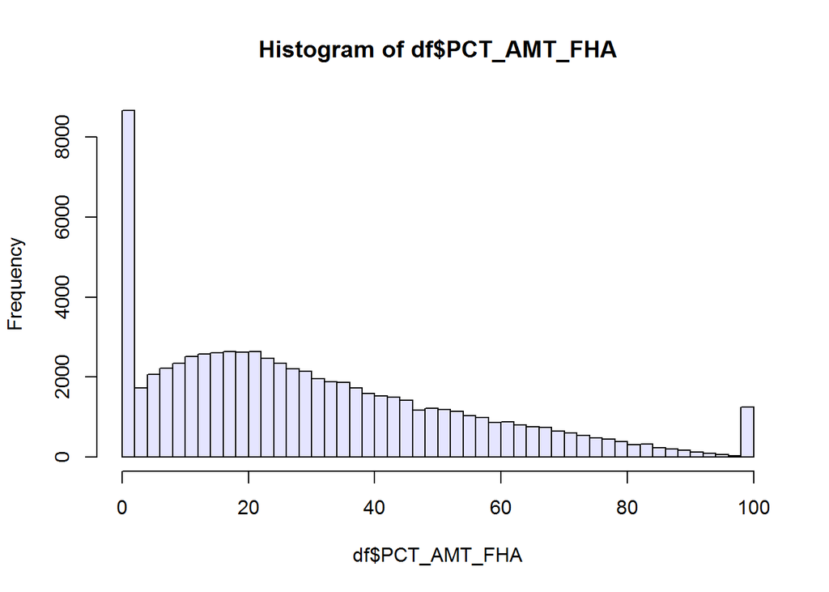

```r
hist(df$PCT_AMT_FHA, breaks=50, col = rgb( 0, 0, 1, 0.1))
```

Siccome la distribuzione ha una coda estesa sulla destra, trasformiamo la variabile nel suo logaritmo.  
Creo una nuova colonna, visualizzo le caratteristiche principali e l’istogramma:

```r
df$LOG_AMT_ALL = log1p(df$AMT_ALL)
summary(df$LOG_AMT_ALL)
```

```
##    Min. 1st Qu.  Median    Mean 3rd Qu.    Max.
##   1.099   7.347   8.335   8.170   9.177  14.270
```

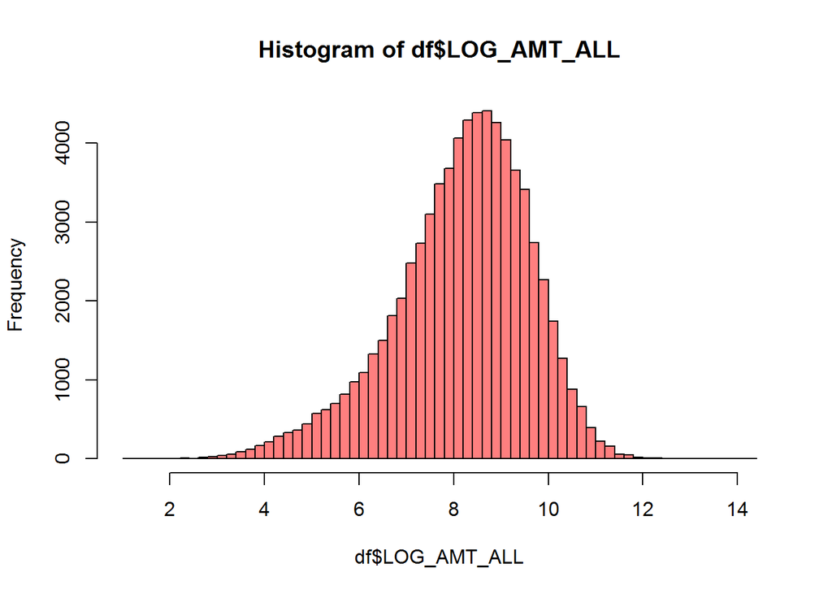

```r
hist(df$LOG_AMT_ALL, breaks = 50, col = rgb(1, 0, 0, 0.5))
```

Applico una funzione e plotto direttamente il risultato, senza modificare il dataframe:

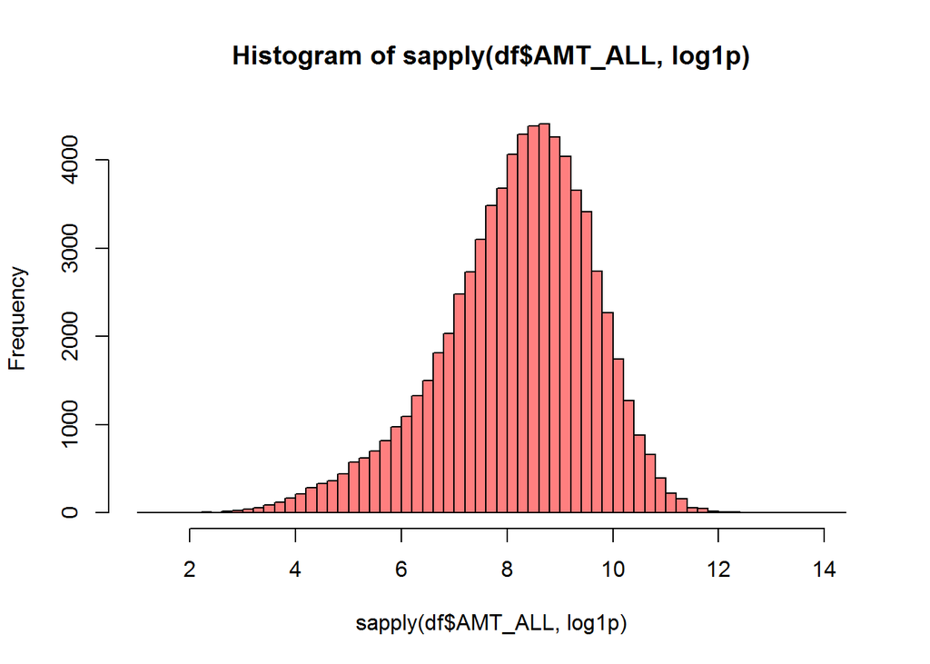

```r
hist(sapply(df$AMT_ALL, log1p), breaks = 50, col = rgb(1, 0, 0, 0.5))
```

# Indexing data frames

Richiamando la funzione head ad una colonna di un dataframe, R restituisce un vettore di valori:

```r
head(df$State_Code)
```

```
## [1]  8 28 40 39 12 12
```

Per ottenere un sottoinsieme di un dataframe:

```r
head(df[,c("State_Code","County_Code")])
```

```
##   State_Code County_Code
## 1          8          75
## 2         28          49
## 3         40           3
## 4         39         113
## 5         12         105
## 6         12          86
```

Per recuperare i nomi delle colonne di un dataframe:

```r
colnames(df)
```

```
##  [1] "State_Code"          "County_Code"         "Census_Tract_Number"
##  [4] "NUM_ALL"             "NUM_FHA"             "PCT_NUM_FHA"
##  [7] "AMT_ALL"             "AMT_FHA"             "PCT_AMT_FHA"
## [10] "GEOID"               "LOG_AMT_ALL"
```

Per selezionare delle righe specifiche:

```r
df[1:4,]
```

```
##   State_Code County_Code Census_Tract_Number NUM_ALL NUM_FHA PCT_NUM_FHA
## 1          8          75                  NA       1       1         100
## 2         28          49              103.01       1       1         100
## 3         40           3                  NA       1       1         100
## 4         39         113              603.00       3       3         100
##   AMT_ALL AMT_FHA PCT_AMT_FHA       GEOID LOG_AMT_ALL
## 1     258     258         100          NA    5.556828
## 2      71      71         100 28049010301    4.276666
## 3     215     215         100          NA    5.375278
## 4     206     206         100 39113060300    5.332719
```

Per indicizzare un particolare elemento del dataframe, riga 4 e colonna 3:

```r
df[4,3]
```

```
## [1] 603
```

Per ottenere i valori compresi dalla riga 1 alla 4, e dalla colonna 4 alla 6, compresi:

```r
df[1:4, 4:6]
```

```
##   NUM_ALL NUM_FHA PCT_NUM_FHA
## 1       1       1         100
## 2       1       1         100
## 3       1       1         100
## 4       3       3         100
```

Oppure utilizzando i nomi delle colonne:

```r
df[1:4, c("State_Code","Census_Tract_Number")]
```

```
##   State_Code Census_Tract_Number
## 1          8                  NA
## 2         28              103.01
## 3         40                  NA
## 4         39              603.00
```

# Filtering data

Mi restituisce un vettore di booleani dove State_Code = 1:

```r
head(df$State_Code == 1)
```

```
## [1] FALSE FALSE FALSE FALSE FALSE FALSE
```

Mi restituisce un vettore di booleani dove State_Code = 1 e Census_Tract_Number = 9613:

```r
head(df$State_Code == 1 & df$Census_Tract_Number == 9613)
```

```
## [1] FALSE FALSE FALSE FALSE FALSE FALSE
```

Visualizzo le righe del dataframe solo dove State_Code = 5:

```r
head(df[df$State_Code == 5,])
```

```
##      State_Code County_Code Census_Tract_Number NUM_ALL NUM_FHA
## 78            5         119               32.05       1       1
## 187           5          69               19.01       2       2
## 905           5         119               12.00       2       2
## 987           5         119               40.01       4       4
## 1253          5         119                5.00       5       4
## 1662          5          69               14.02       7       6
##      PCT_NUM_FHA AMT_ALL AMT_FHA PCT_AMT_FHA      GEOID LOG_AMT_ALL
## 78      100.0000     113     113    100.0000 5119003205    4.736198
## 187     100.0000     224     224    100.0000 5069001901    5.416100
## 905     100.0000     154     154    100.0000 5119001200    5.043425
## 987     100.0000     445     445    100.0000 5119004001    6.100319
## 1253     80.0000     307     301     98.0456 5119000500    5.730100
## 1662     85.7143     405     360     88.8889 5069001402    6.006353
```

# Joining data

```r
df_geo = read.csv('C:/Users/luca.ganugi/Desktop/Master MABIDA/Gigli/Data Reply/2013_Gaz_tracts_national.tsv', sep = '\t')
head(df_geo)
```

```
##   USPS      GEOID    ALAND AWATER ALAND_SQMI AWATER_SQMI INTPTLAT
## 1   AL 1001020100  9809939  36312      3.788       0.014 32.48179
## 2   AL 1001020200  3340498   5846      1.290       0.002 32.47576
## 3   AL 1001020300  5349274   9054      2.065       0.003 32.47402
## 4   AL 1001020400  6382705  16244      2.464       0.006 32.47103
## 5   AL 1001020500 11397734  48412      4.401       0.019 32.45892
## 6   AL 1001020600  8020363  60048      3.097       0.023 32.44737
##   INTPTLONG
## 1 -86.49025
## 2 -86.47247
## 3 -86.45970
## 4 -86.44484
## 5 -86.42182
## 6 -86.47683
```

Left join tra df e df_geo sul campo GEOID:

```r
df_joined = merge(df,df_geo, by="GEOID", all.x= TRUE) #left join
head(df_joined)
```

```
##        GEOID State_Code County_Code Census_Tract_Number NUM_ALL NUM_FHA
## 1 1001020100          1           1                 201       8       5
## 2 1001020200          1           1                 202      12       5
## 3 1001020300          1           1                 203      38      20
## 4 1001020400          1           1                 204      30      16
## 5 1001020500          1           1                 205     104      25
## 6 1001020600          1           1                 206      28      12
##   PCT_NUM_FHA AMT_ALL AMT_FHA PCT_AMT_FHA LOG_AMT_ALL USPS    ALAND AWATER
## 1     62.5000    1319     754     57.1645    7.185387   AL  9809939  36312
## 2     41.6667    1241     414     33.3602    7.124478   AL  3340498   5846
## 3     52.6316    3605    1928     53.4813    8.190354   AL  5349274   9054
## 4     53.3333    3628    1800     49.6141    8.196712   AL  6382705  16244
## 5     24.0385   18591    3692     19.8591    9.830487   AL 11397734  48412
## 6     42.8571    4076    1493     36.6290    8.313117   AL  8020363  60048
##   ALAND_SQMI AWATER_SQMI INTPTLAT INTPTLONG
## 1      3.788       0.014 32.48179 -86.49025
## 2      1.290       0.002 32.47576 -86.47247
## 3      2.065       0.003 32.47402 -86.45970
## 4      2.464       0.006 32.47103 -86.44484
## 5      4.401       0.019 32.45892 -86.42182
## 6      3.097       0.023 32.44737 -86.47683
```

# Aggregating data

Filtro solo le righe con valore USPS=AK:

```r
head(df_joined[df_joined$USPS=='AK',])
```

```
##          GEOID State_Code County_Code Census_Tract_Number NUM_ALL NUM_FHA
## 1113 2.013e+09          2          13                1.00       1       0
## 1114 2.016e+09          2          16                2.00       3       0
## 1115 2.020e+09          2          20                1.01      89      15
## 1116 2.020e+09          2          20                1.02      51       6
## 1117 2.020e+09          2          20                2.01     103      17
## 1118 2.020e+09          2          20                2.02      99      22
##      PCT_NUM_FHA AMT_ALL AMT_FHA PCT_AMT_FHA LOG_AMT_ALL USPS       ALAND
## 1113      0.0000      68       0      0.0000    4.234107   AK 18082854844
## 1114      0.0000     828       0      0.0000    6.720220   AK  2823181227
## 1115     16.8539   28650    4041     14.1047   10.262944   AK  1598886203
## 1116     11.7647   15255    1631     10.6916    9.632728   AK   168784417
## 1117     16.5049   28350    3635     12.8219   10.252418   AK     3301593
## 1118     22.2222   30681    6216     20.2601   10.331431   AK     9181044
##           AWATER ALAND_SQMI AWATER_SQMI INTPTLAT INTPTLONG
## 1113 20793145269   6981.830    8028.279 55.44133 -161.9555
## 1114  3101986208   1090.036    1197.684 53.62109 -166.7710
## 1115    66040634    617.333      25.498 61.29935 -149.0211
## 1116    15088676     65.168       5.826 61.34882 -149.3998
## 1117       35499      1.275       0.014 61.33307 -149.5736
## 1118           0      3.545       0.000 61.32863 -149.5380
```

Ottengo la media per gruppi by USPS di tutte le colonne del df_joined:

```r
usps_groups_mean = aggregate(. ~ USPS, df_joined , mean)
```

This is the analog of SELECT USPS, SUM(AMT_FHA), SUM(AMT_ALL), … FROM df GROUP BY USPS:

```r
df_by_state = aggregate(cbind(AMT_FHA, AMT_ALL, NUM_FHA, NUM_ALL) ~ USPS, df_joined , sum)
head(df_by_state)
```

```
##   USPS  AMT_FHA  AMT_ALL NUM_FHA NUM_ALL
## 1   AK   438666  1880062    1850    7411
## 2   AL  1237209  5771053    9267   35766
## 3   AR   742675  3613515    5663   25500
## 4   AZ  3489785 13773032   22360   75226
## 5   CA 22607179 99817500   88650  307087
## 6   CO  3463221 17390580   17932   73352
```

Introduco un nuovo campo:

```r
df_by_state$PCT_AMT_FHA = 100.0 * df_by_state$AMT_FHA  / df_by_state$AMT_ALL
```

This sure looks different than the census-tract level histogram!:

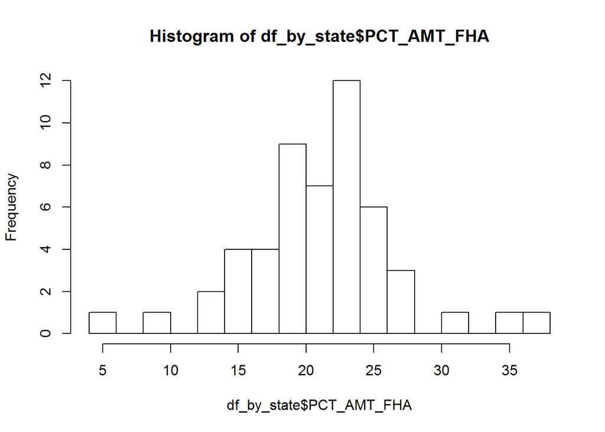

```r
hist(df_by_state$PCT_AMT_FHA, breaks = 20)
```

Dataframe con 2 colonne a cui sono state applicate funzioni diverse:

```r
head(merge(aggregate(NUM_ALL ~ USPS, df_joined, mean), aggregate(NUM_FHA ~ USPS, df_joined, sum), by="USPS"))
```

```
##   USPS  NUM_ALL NUM_FHA
## 1   AK 49.07947    1850
## 2   AL 32.16367    9267
## 3   AR 37.94643    5663
## 4   AZ 52.27658   22360
## 5   CA 39.15428   88650
## 6   CO 59.83034   17932
```

Creo un dataframe raggruppato per USPS:

```r
usps_groups = group_by(df_joined,USPS)
```

Utilizzo dplyr per ordinare il dataframe sulla colonna INTPTLAT in senso discendente:

```r
arrange(usps_groups,desc(INTPTLAT))[1,]
```

```
## Source: local data frame [1 x 18]
## Groups: USPS [1]
##
##       GEOID State_Code County_Code Census_Tract_Number NUM_ALL NUM_FHA
##       <dbl>      <int>       <int>               <dbl>   <int>   <int>
## 1 2.185e+09          2         185                   1      11       8
## # ... with 12 more variables: PCT_NUM_FHA <dbl>, AMT_ALL <int>,
## #   AMT_FHA <int>, PCT_AMT_FHA <dbl>, LOG_AMT_ALL <dbl>, USPS <fctr>,
## #   ALAND <dbl>, AWATER <dbl>, ALAND_SQMI <dbl>, AWATER_SQMI <dbl>,
## #   INTPTLAT <dbl>, INTPTLONG <dbl>
```

Creo una funzione in cui per ogni valore di USPS mi restituisce il massimo di INTPTLAT:

```r
farthest_north = function(state_df){
  result = arrange(state_df,desc(INTPTLAT))[1,]
  return (result)
}
```

Creo un dataframe che mi restituisce, per valore univoco di USPS, il valore massimo trovato nella colonna INTPTLAT:

```r
northest = summarise(usps_groups,farthest_north=max(INTPTLAT))
northest
```

```
## # A tibble: 53 × 2
##      USPS farthest_north
##    <fctr>          <dbl>
## 1      AK       71.28794
## 2      AL       34.96529
## 3      AR       36.48628
## 4      AZ       36.91659
## 5      CA       41.94665
## 6      CO       40.92410
## 7      CT       42.02461
## 8      DC       38.98497
## 9      DE       39.83222
## 10     FL       30.96749
## # ... with 43 more rows
```

# Sorting by indices and columns

Sort by index:

```r
head(df_by_state[order(row.names(df_by_state), decreasing = TRUE),])
```

```
##    USPS AMT_FHA  AMT_ALL NUM_FHA NUM_ALL PCT_AMT_FHA
## 9    DE  423161  1997634    2273    9105    21.18311
## 8    DC  403218  2751323    1154    6605    14.65542
## 7    CT 1429631  7665951    7069   26614    18.64910
## 6    CO 3463221 17390580   17932   73352    19.91435
## 52   WY  248573  1313697    1418    6644    18.92164
## 51   WV  282703  1675079    2129   11739    16.87700
```

Sort by valori in una colonna:

```r
head(df_by_state[order(df_by_state$AMT_FHA, decreasing = TRUE),])
```

```
##    USPS  AMT_FHA  AMT_ALL NUM_FHA NUM_ALL PCT_AMT_FHA
## 5    CA 22607179 99817500   88650  307087    22.64851
## 45   TX 10789870 45870174   73549  243977    23.52263
## 10   FL  6866263 30754332   44511  157431    22.32617
## 35   NY  5578590 30631391   25019  101335    18.21200
## 47   VA  4713396 23048658   20495   85169    20.44976
## 39   PA  3956081 17140876   25989   94954    23.07981
```

# Unique values

Valori univoci della colonna State_Code (primi 10 valori):

```r
unique(df$State_Code)[1:10]
```

```
##  [1]  8 28 40 39 12 36 48 13 17 34
```

Count della frequenza di State_Code, in senso decrescente:

```r
head(sort(table(df$State_Code), decreasing = TRUE))
```

```
##
##    6   48   36   12   42   17
## 7872 5092 4629 4099 3184 3048
```

Verifica della presenza degli elementi di State_Code nei primi 3 valori (restituisce una lista di booleani):

```r
head(is.element(df$State_Code,head(df$State_Code,3)))
```

```
## [1]  TRUE  TRUE  TRUE FALSE FALSE FALSE
```

# Handling missing and NA data

Primi 10 valori di GEOID:

```r
df$GEOID[1:10]
```

```
##  [1]          NA 28049010301          NA 39113060300 12105012404
##  [6] 12086980800 39035120200 12103020700 36119003000          NA
```

Ottengo una lista di boleani:

```r
is.na(df$GEOID[1:10])
```

```
##  [1]  TRUE FALSE  TRUE FALSE FALSE FALSE FALSE FALSE FALSE  TRUE
```

Lunghezza del vettore GEOID:

```r
length(df$GEOID)
```

```
## [1] 72035
```

Conta dei valori non nulli in GEOID:

```r
sum(!is.na(df$GEOID))
```

```
## [1] 71040
```

Sostituisco i valori null di GEOID con:

```r
df$GEOID0 = replace(df$GEOID,is.na(df$GEOID),0) #inserendo gli 0
df$GEOIDinterp = na.approx(df$GEOID, na.rm = FALSE) #interpolando i valori
df$GEOIDmean = na.aggregate(df$GEOID,fun=mean) #inserisco il valore medio della colonna
df$GEOIDforw = na.locf0(df$GEOID) #fill forward
df$GEOIDback = na.locf0(df$GEOID, fromLast = TRUE)  #fill backward
```

Riepilogo e confronto:

```r
head(df[,c('GEOID','GEOID0','GEOIDinterp','GEOIDmean','GEOIDforw','GEOIDback')],10)
```

```
##          GEOID      GEOID0 GEOIDinterp   GEOIDmean   GEOIDforw   GEOIDback
## 1           NA           0          NA 28373187314          NA 28049010301
## 2  28049010301 28049010301 28049010301 28049010301 28049010301 28049010301
## 3           NA           0 33581035301 28373187314 28049010301 39113060300
## 4  39113060300 39113060300 39113060300 39113060300 39113060300 39113060300
## 5  12105012404 12105012404 12105012404 12105012404 12105012404 12105012404
## 6  12086980800 12086980800 12086980800 12086980800 12086980800 12086980800
## 7  39035120200 39035120200 39035120200 39035120200 39035120200 39035120200
## 8  12103020700 12103020700 12103020700 12103020700 12103020700 12103020700
## 9  36119003000 36119003000 36119003000 36119003000 36119003000 36119003000
## 10          NA           0 42116005852 28373187314 36119003000 48113008704
```

# Note

```r
text_series <- as.character(sprintf("%.1f",replace(df$GEOID,is.na(df$GEOID),0)))
head(text_series,10)
```

```
##  [1] "0.0"           "28049010301.0" "0.0"           "39113060300.0"
##  [5] "12105012404.0" "12086980800.0" "39035120200.0" "12103020700.0"
##  [9] "36119003000.0" "0.0"
```

```r
text.split = unlist(strsplit(text_series, split = ".", fixed = TRUE))
head(text.split)
```

```
## [1] "0"           "0"           "28049010301" "0"           "0"
## [6] "0"
```

Valore medio della colonna GEOID, ottenuto rimuovendo i valori nulli:

```r
mean(df$GEOID, na.rm = TRUE)
```

```
## [1] 28373187314
```

# Manipulating strings

Seleziono solo i valori non nulli di USPS:

```r
states = df_joined$USPS[!is.na(df_joined$USPS)]
```

Mi restituisce i valori di states contenenti A:

```r
head(states[grepl('A', states)])
```

```
## [1] AL AL AL AL AL AL
## 52 Levels: AK AL AR AZ CA CO CT DC DE FL GA HI IA ID IL IN KS KY LA ... WY
```

# Indices in Pandas

Non mi riesce di trovare il modo di sommare per index:

```r
s1 <- c(1, 2, 3)
s2 <- c(3, 2, 1)
s1 + s2
```

```
## [1] 4 4 4
```

```r
s3 <- c(3, 2, 1)
s1 + s3
```

```
## [1] 4 4 4
```

# Function application and mapping

Creo un dataframe di 24 numeri, dallo 0 al 23, in 4 righe e 6 colonne

```r
df1 <- as.data.frame(matrix(0:23, ncol = 6, nrow = 4,byrow = TRUE))
```

Applico la funzione seno a tutti gli elementi:

```r
head(sin(df1))
```

```
##           V1        V2        V3        V4           V5         V6
## 1  0.0000000 0.8414710 0.9092974 0.1411200 -0.756802495 -0.9589243
## 2 -0.2794155 0.6569866 0.9893582 0.4121185 -0.544021111 -0.9999902
## 3 -0.5365729 0.4201670 0.9906074 0.6502878 -0.287903317 -0.9613975
## 4 -0.7509872 0.1498772 0.9129453 0.8366556 -0.008851309 -0.8462204
```

Formatto i numeri del df1 mediante una funzione:

```r
apply(df1,1:2, function(x) sprintf("%.2f",x))
```

```
##      V1      V2      V3      V4      V5      V6
## [1,] "0.00"  "1.00"  "2.00"  "3.00"  "4.00"  "5.00"
## [2,] "6.00"  "7.00"  "8.00"  "9.00"  "10.00" "11.00"
## [3,] "12.00" "13.00" "14.00" "15.00" "16.00" "17.00"
## [4,] "18.00" "19.00" "20.00" "21.00" "22.00" "23.00"
```

Funzione differenza:

```r
apply(df1,1, function(x) max(x)-min(x)) #differenze per riga
```

```
## [1] 5 5 5 5
```

```r
apply(df1,2, function(x) max(x)-min(x)) #differenze per colonna
```

```
## V1 V2 V3 V4 V5 V6
## 18 18 18 18 18 18
```

# Pandas HTML data import example

```r
url = "http://en.wikipedia.org/wiki/List_of_tallest_buildings_and_structures_in_the_world"
```

Importo nell’oggetto tallest i dati dal sito web:

```r
tallest = htmltab(doc = url, which = 3, encoding = "UTF-8", lang="en", parse_dates=False)
```

Creo un oggetto tl contenente le coordinate estratte tramite regulary expression:

```r
tl = t(as.data.frame(stri_extract_all(tallest$Coordinates, regex = "-?\\d{1,3}+\\.?\\d{4,6}")))
```

Inserisco nel dataframe tallest i 2 vettori longitude e latitude:

```r
tallest$Longitude = tl[, 4]
tallest$Latitude = tl[, 3]
#Et voila
head(tallest)
```

```
##                   Category                      Structure
## 2                Mixed use                   Burj Khalifa
## 3    Self-supporting tower                  Tokyo Skytree
## 4 Guyed steel lattice mast                   KVLY-TV mast
## 5           Clock building           Abraj Al Bait Towers
## 6                   Office         One World Trade Center
## 7       Military structure Large masts of INS Kattabomman
##                  Country                    City Height (metres)
## 2 Â United Arab Emirates                   Dubai           828.1
## 3                Â Japan                   Tokyo             634
## 4        Â United States Blanchard, North Dakota           628.8
## 5         Â Saudi Arabia                   Mecca             601
## 6        Â United States            New York, NY             541
## 7                Â India             Tirunelveli             471
##   Height (feet) Year built
```

[output cut: 20 more lines]

# Pandas Timestamps

```r
Sys.setlocale("LC_TIME", "C")
```

```
## [1] "C"
```

```r
as.POSIXct("July 4, 2016",format='%B %d, %Y')
```

```
## [1] "2016-07-04 CEST"
```

```r
as.POSIXlt('Monday, July 4, 2016', format = "%A, %B %d, %Y")
```

```
## [1] "2016-07-04 CEST"
```

```r
as.POSIXlt('Tuesday, July 4th, 2016', format = "%A, %B %dth, %Y")
```

```
## [1] "2016-07-04 CEST"
```

```r
as.POSIXlt('Monday, July 4th, 2016 05:00 PM', format = "%A, %B %dth, %Y %I:%M %p")
```

```
## [1] "2016-07-04 17:00:00 CEST"
```

```r
as.POSIXlt('04/07/2016T17:20:13.123456', format = "%d/%m/%YT%H:%M:%OS")
```

```
## [1] "2016-07-04 17:20:13 CEST"
```

```r
as.Date(as.POSIXlt(1467651600000000000/1000000000, origin="1970-01-01"))
```

```
## [1] "2016-07-04"
```

```r
july4 = as.POSIXlt('Monday, July 4th, 2016 05:00 PM', format = "%A, %B %dth, %Y %I:%M %p", tz = "US/Eastern")
labor_day = as.POSIXlt('9/5/2016 12:00', format = "%d/%m/%Y %H:%M", tz = "US/Eastern")
thanksgiving = as.POSIXlt('11/24/2016 16:00', format = "%m/%d/%Y %H:%M") # no timezone
```

Differenze tra date:

```r
labor_day - july4
```

```
## Time difference of -56.20833 days
```

```r
thanksgiving - july4 #a differenza di pandas anche se le timezones sono differenti il calcolo viene eseguito
```

```
## Time difference of 142.75 days
```

```r
seq.POSIXt( from=july4, by="5 day", length.out=2 )[2]# 5 calendar days later, a Saturday.
```

```
## [1] "2016-07-09 17:00:00 EDT"
```

Creo una funzione per ricavare l’ultimo giorno del mese:

```r
last_day_month <- function(date) {
  ceiling_date(date, "month") - days(1)
}
last_day_month(ymd(20160704)) #last  day of the month.
```

```
## [1] "2016-07-31"
```

Creo un calendario chiamato cal, in cui setto sabato e domenica come non lavorativi:

```r
create.calendar(name='test', holidays=holidaysANBIMA, weekdays=c('saturday', 'sunday'))
bizdays.options$set(default.calendar='test')
cal = bizdays.options$get("default.calendar")
```

Aggiungo a july4:

```r
offset(july4, 5, cal) #5 giorni lavorativi
```

```
## [1] "2016-07-11"
```

```r
offset(july4, -1, cal) #-1 giorno lavorativo
```

```
## [1] "2016-07-01"
```

L’ultimo giorno lavorativo di luglio:

```r
offset(last_day_month(ymd(20160704)), -1, cal)
```

```
## [1] "2016-07-29"
```

Genero una lista di date lavorative del 2016:

```r
business_days = bizseq('2016-01-01', '2016-12-31', "test")
head(business_days)
```

```
## [1] "2016-01-04" "2016-01-05" "2016-01-06" "2016-01-07" "2016-01-08"
## [6] "2016-01-11"
```

Creo una tabella contenente i giorni lavorativi e un indice generato casualmente:

```r
tabella = data.frame(business_days, sample(1:length(business_days), replace = FALSE))
row.names(tabella) = seq(1, length(business_days))
colnames(tabella) = c('Giorno lavorativo','N°')
head(tabella)
```

```
##   Giorno lavorativo  N°
## 1        2016-01-04 156
## 2        2016-01-05   8
## 3        2016-01-06  27
## 4        2016-01-07 118
## 5        2016-01-08 207
## 6        2016-01-11  15
```

Campiono 5 giorni dalla lista business_days:

```r
date = sample(business_days, size=5, replace = FALSE)
```

Converto date in un vettore di ‘date’ :

```r
tempdate = as.POSIXct(date)
cbind(US = format(tempdate, tz="America/New_York"), UK = format(tempdate, tz = "Europe/Rome"))
```

```
##      US                    UK
## [1,] "2016-03-08 19:00:00" "2016-03-09 01:00:00"
## [2,] "2016-05-22 20:00:00" "2016-05-23 02:00:00"
## [3,] "2016-10-16 20:00:00" "2016-10-17 02:00:00"
## [4,] "2016-05-17 20:00:00" "2016-05-18 02:00:00"
## [5,] "2016-01-06 19:00:00" "2016-01-07 01:00:00"
```

# Multi-indices, stacking, and pivot tables

Creo group1, raggruppando per State_Code e County_Code la tabella df_joined e sommo i campi NUM_ALL e NUM_FHA:

```r
group1 = group_by(df_joined, State_Code, County_Code)
group2 = summarise(group1, NUM_ALL = sum(NUM_ALL), NUM_FHA = sum(NUM_FHA))
head(group2)
```

```
## Source: local data frame [6 x 4]
## Groups: State_Code [1]
##
##   State_Code County_Code NUM_ALL NUM_FHA
##        <int>       <int>   <int>   <int>
## 1          1           1     466     147
## 2          1           3    2565     417
## 3          1           5      52       8
## 4          1           7      68      20
## 5          1           9     352      97
## 6          1          11       9       1
```

E’ possibile usare come indice State_Code e come colonna County_Code ed avere come valori di incrocio NUM_ALL:

```r
unstacked = dcast(group2, State_Code ~ County_Code, value.var = "NUM_ALL")
head(unstacked[,1:7])
```

```
##   State_Code     1    3    5  6    7   9
## 1          1   466 2565   52 NA   68 352
## 2          2    NA   NA   NA NA   NA  NA
## 3          4    91  877 1160 NA  416 248
## 4          5   117   53  358 NA 3635 311
## 5          6 13591   17  408 NA 1629 611
## 6          8  5755   35 8304 NA   94   4
```

# Seconda parte

```r
#Creo la funzione geocode, che prende in carico un address ed esegue una query sul sito Openstreetmap, restituendo latitudine e longitudine.
geocode <- function(address){
  parameters = list(q=address,addressdetails=1,format="json")
  endpointUrl = "http://nominatim.openstreetmap.org/search"
  result_g = GET(endpointUrl, query=parameters)
  addressList = content(result_g,as = "parsed")
  return(c(addressList[[1]]$lat, addressList[[1]]$lon))
}

address<-"1600 Pennsylvania Avenue, Washington, DC"
response = geocode(address)
response
```

```
## [1] "38.8636383"  "-76.9463651"
```

```r
#La funzione weather_at_address invece sfrutta le coordinate generate dalla precedente funzione per restituire il meteo di un particolare indirizzo.
weather_at_address = function (address) {
  response = geocode(address)
  parameters = list(lat=response[1],lon=response[2],FcstType="json")
  endpointUrl = "http://forecast.weather.gov/MapClick.php"
  result_w = GET(endpointUrl, query=parameters)
  weatherList = content(result_w,as = "parsed")
  return(data.frame(Meteo=weatherList$currentobservation$Weather,Temp=weatherList$currentobservation$Temp))
}

weather = weather_at_address(address)
weather
```

```
##           Meteo Temp
## 1 Mostly Cloudy   77
```